# Nanofish: Speed during feeding

# Set up environment

## Load libraries

## Load functions

## Load data

### Adjust classes and transformations

```
'data.frame':   467 obs. of  30 variables:
 $ StudyID             : Factor w/ 59 levels "2","3","4","5",..: 40 40 50 50 50 50 16 16 16 7 ...
 $ StudyCluster        : Factor w/ 34 levels "1","2","3","5",..: 4 4 5 5 5 5 4 4 4 18 ...
 $ Study               : Factor w/ 59 levels "Ašmonaitė et al., 2020",..: 1 1 2 2 2 2 3 3 3 4 ...
 $ Year                : int  2020 2020 2018 2018 2018 2018 2020 2020 2020 2019 ...
 $ EScluster           : Factor w/ 101 levels "1","2","3","4",..: 1 1 2 2 2 2 3 3 3 4 ...
 $ AdministrationRoute : Factor w/ 6 levels "Food","Injection",..: 1 1 4 4 4 4 1 1 1 4 ...
 $ Concentration_mg_L  : num  NA NA 0.26 0.69 0.26 0.69 NA NA NA 20 ...
 $ ParticleMaterial    : Factor w/ 6 levels "Aminoplast","PE",..: 5 2 1 1 1 1 2 2 2 5 ...
 $ Species             : Factor w/ 20 levels "Argyrosomus regius",..: 9 9 8 8 8 8 9 9 9 7 ...
 $ ParticleShape       : Factor w/ 4 levels "Irregular","Sphere",..: 2 2 2 2 2 2 2 2 2 2 ...
 $ Sex                 : Factor w/ 4 levels "F","F:M","M",..: 4 4 NA NA NA NA 4 4 4 NA ...
 $ DevelopmentalStage  : Factor w/ 5 levels "Embrio","Larva",..: 4 4 3 3 3 3 4 4 4 2 ...
 $ ExposureDurationCat : Factor w/ 3 levels "15 days +","5-15 days",..: 2 2 3 3 3 3 1 1 1 3 ...
 $ ExposureDurationDays: int  14 14 4 4 4 4 28 28 28 2 ...
```

[output cut: 16 more lines]

### Calculate Effect Size

```r
df_original <- metafor::escalc(measure = "SMD", n1i = n_treat, n2i = n_ctrl, m1i = mean_treat,
    m2i = mean_ctrl, sd1i = STD_treat, sd2i = STD_ctrl, data = df_original, vtype = "UB")
write.csv(df_original, file = "mvMetaAnalysis_SMDs.csv")
```

### Create variables

```r
outcome <- as.character(outcomeslist[[n_outcome]])

mRF <- list()  # random effects formula investigation models
mRE <- list()  # random effects multilevel models
mMR <- list()  # multilevel metaregression models

colormap <- c(Embrio = "khaki", Larva = "lightgreen", Juvenile = "lightskyblue",
    Adult = "salmon", Unclear = "plum", ExposureDurationDays = "cornflowerblue",
    ParticleSizeMean = "chartreuse4", Concentration_mg_L = "#fa0079ff", Aminoplast = "chocolate4",
    LDPE = "#2200faff", PE = "#0089faff", PET = "#00faedff", PLA = "#00fa29ff", PS = "#faf200ff",
    PVC = "#fa9a00ff", `Publication year` = "black", Variance = "navyblue")
```

### Select outcome data

```
[1] "Speed during feeding"
```

|  | StudyID | StudyCluster | Study | Year | EScluster | AdministrationRoute | Concentration_mg_L | ParticleMaterial | Species | ParticleShape | Sex | DevelopmentalStage | ExposureDurationCat | ExposureDurationDays | ParticleSizeRange | ParticleSizeMean | ParticleSizeCat | Outcome | OutcomeCategory | Test_or_Assay | OutcomeVariable | Group | n_of_groups | n_ctrl | mean_ctrl | STD_ctrl | n_treat | mean_treat | STD_treat | … |
| --- | --- | --- | --- | --- | --- | --- | --- | --- | --- | --- | --- | --- | --- | --- | --- | --- | --- | --- | --- | --- | --- | --- | --- | --- | --- | --- | --- | --- | --- | --- |
| 122 | 18 | 31 | Guven et al., 2018 | 2018 | 44 | Water: Static system |  | PS | Lates calcarifer | Sphere |  | Larva | up to 96h | 1 | 97 | 97 | micro | Speed during feeding | Feeding behaviour | Locomotor activity | Speed during feeding | MPs | 1 | 18 | 4.911 | 4.581 | 18 | 3.033 | 2.311 | … |
| 174 | 26 | 19 | Mattsson et al., 2015 | 2015 | 55 | Food |  | PS | Carassius carassius | Unclear | Unclear | Adult | 15 days + | 61 | 0.025 | 0.025 | nano | Speed during feeding | Feeding behaviour | Locomotor activity | Speed during feeding | Nano | 1 | 6 | 37.395 | 4.174 | 6 | 24.536 | 1.518 | … |
| 178 | 21 | 19 | Mattsson et al., 2017 | 2017 | 56 | Food |  | PS | Carassius carassius | Unclear | Unclear | Adult | 15 days + | 67 | 0.053 | 0.053 | nano | Speed during feeding | Feeding behaviour | Locomotor activity | Speed during feeding | 53 nm | 3 | 6 | 26.002 | 2.438 | 5 | 23.039 | 2.809 | … |
| 179 | 21 | 19 | Mattsson et al., 2017 | 2017 | 56 | Food |  | PS | Carassius carassius | Unclear | Unclear | Adult | 15 days + | 67 | 0.18 | 0.18 | nano | Speed during feeding | Feeding behaviour | Locomotor activity | Speed during feeding | 180 nm | 3 | 6 | 26.002 | 2.438 | 6 | 30.876 | 2.441 | … |
| 180 | 21 | 19 | Mattsson et al., 2017 | 2017 | 56 | Food |  | PS | Carassius carassius | Unclear | Unclear | Adult | 15 days + | 67 | 0.053 | 0.053 | nano | Speed during feeding | Feeding behaviour | Locomotor activity | Speed during feeding | 53 nm 0.029g/L | 3 | 6 | 26.002 | 2.438 | 6 | 31 | 0.842 | … |
| 451 | 72 | 20 | Yin et al., 2018 | 2018 | 96 | Water: Semi-static system |  | PS | Sebastes schlegelii | Sphere |  | Juvenile | 5-15 days | 14 | 15 | 15 | micro | Speed during feeding | Feeding behaviour | Locomotor activity | Speed during feeding | MP (10^6 particles/L) | 1 | 30 | 4.679 | 0.938 | 30 | 2.629 | 0.504 | … |
| 452 | 16 | 20 | Yin et al., 2019 | 2019 | 97 | Water: Unclear | 0.19 | PS | Sebastes schlegelii | Sphere |  | Juvenile | 5-15 days | 14 | 0.5 | 0.5 | nano | Speed during feeding | Feeding behaviour | Locomotor activity | Speed during feeding | 0.5 µm | 2 | 30 | 4.849 | 1.312 | 30 | 4.697 | 0.949 | … |
| 453 | 16 | 20 | Yin et al., 2019 | 2019 | 97 | Water: Unclear | 0.19 | PS | Sebastes schlegelii | Sphere |  | Juvenile | 5-15 days | 14 | 15 | 15 | micro | Speed during feeding | Feeding behaviour | Locomotor activity | Speed during feeding | 15 µm | 2 | 30 | 4.849 | 1.312 | 30 | 2.067 | 0.832 | … |

# Exploratory data analysis

## Funnel plot

> Before running any meta-analytic model, it is important to explore the meta-analytic dataset to search for potential outliers that could represent data extraction errors. (Nakagawa et al. 2022)

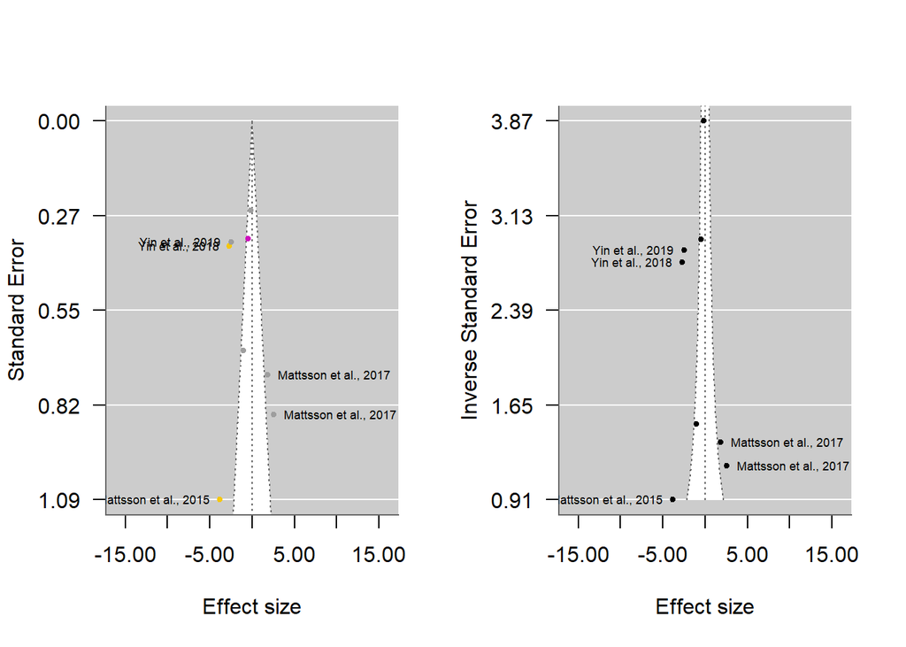

## Alluvial plot

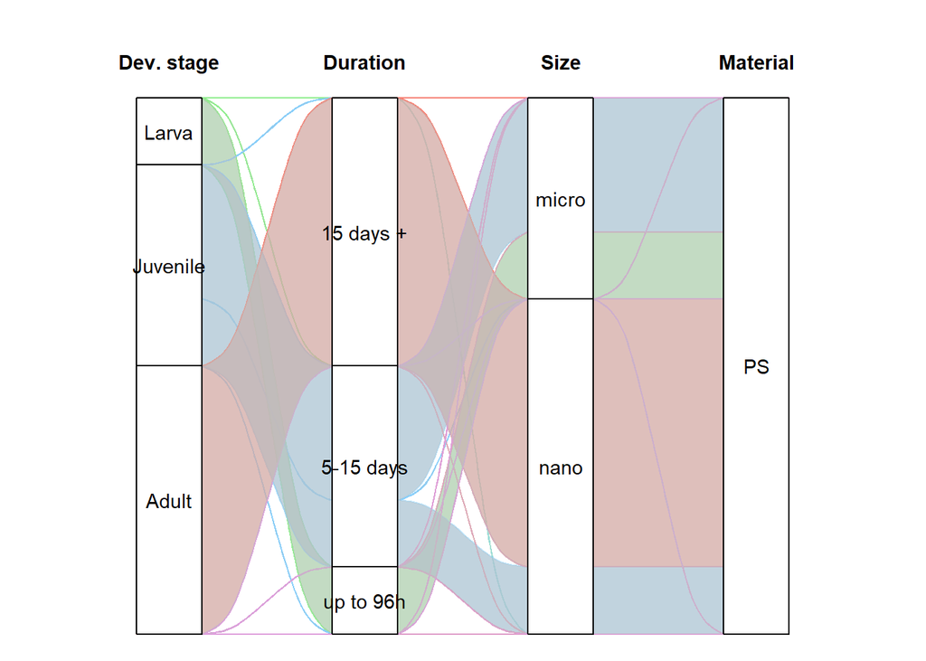

# Multilevel meta-analytic model

## Random effects formula desing

```
[1] "Considering number of studies: 5, number of ES clusters: 5 and number of independent observations of ES: 8, the random effects formula for Speed during feeding is: ~1 | Study/ESid"
```

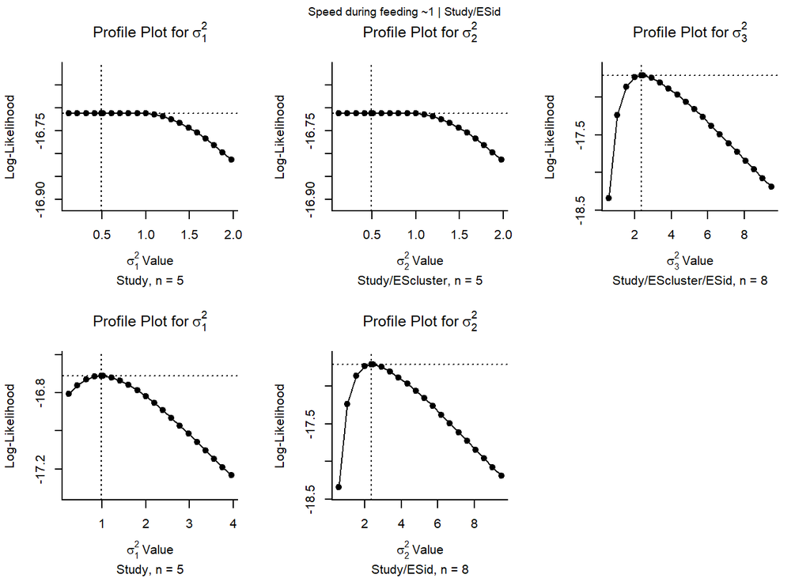

> A profile likelihood plot should show a single peak at the corresponding ML/REML estimate. If `refline=TRUE` (the default), the value of the parameter estimate is indicated by a dotted vertical line and its log-likelihood value by a dotted horizontal line. Hence, the intersection of these two lines should correspond to the peak (assuming that the model was fitted with ML/REML estimation).

> When profiling a variance component (or some other parameter that cannot be negative), the peak may be at zero (if this corresponds to the ML/REML estimate of the parameter). In this case, the profiled log-likelihood should be a monotonically decreasing function of the parameter. Similarly, when profiling a correlation component, the peak may be at -1 or +1.

> If the profiled log-likelihood has multiple peaks, this indicates that the likelihood surface is not unimodal. In such cases, the ML/REML estimate may correspond to a local optimum (when the intersection of the two dotted lines is not at the highest peak).

> If the profile is flat (over the entire parameter space or large portions of it), then this suggests that at least some of the parameters of the model are not identifiable (and the parameter estimates obtained are to some extent arbitrary). See Raue et al. (2009) for some further discussion of parameter identifiability and the use of profile likelihoods to check for this.

> The function checks whether any profiled log-likelihood value is actually larger than the log-likelihood of the fitted model (using a numerical tolerance of `lltol`). If so, a warning is issued as this might indicate that the optimizer did not identify the actual ML/REML estimate of the parameter profiled.[Viechtbauer (2022)](Viechtbauer 2010)

## Additional random effects factors

Study cluster, particle material and species as random effects term can further improve results?

```r
res <- vector("list", 2)

# with selected random effects formula only
mRF[["base"]] <- rma.mv(yi, vi, random = RE_formula, data = df, method = "ML")

# add Study Cluster (nested results were equal)
mRF[["StudyCluster"]] <- rma.mv(yi, vi, random = list(~1 | StudyCluster, RE_formula),
    data = df, method = "ML")

# add Particle Material mRF[['ParticleMat']] <- rma.mv(yi, vi, random =
# list(RE_formula, ~ 1 | ParticleMaterial), data=df, method='ML')

# add Species
mRF[["Species"]] <- rma.mv(yi, vi, random = list(RE_formula, ~1 | Species), data = df,
    method = "ML")

t1 <- data.frame(sapply(mRF, fitstats))
rownames(t1) <- rownames(fitstats(mRF[[1]]))
names(t1) <- c("Nested", "+StudyCluster", "+Species")

DT::datatable(t1)
```

|  | Nested | +StudyCluster | +Species |
| --- | --- | --- | --- |
| logLik: | -16.71210454524047 | -16.71210454660674 | -16.71210454660709 |
| deviance: | 29.31265375219995 | 29.31265375493248 | 29.3126537549332 |
| AIC: | 39.42420909048094 | 41.42420909321347 | 41.42420909321419 |
| BIC: | 39.66253371552044 | 41.74197525993281 | 41.74197525993353 |
| AICc: | 45.42420909048094 | 54.75754242654681 | 54.75754242654752 |

```r
res[[1]] <- anova(mRF[["base"]], mRF[["StudyCluster"]])
# res[[2]] <- anova(mRF[['base']],mRF[['ParticleMat']])
res[[2]] <- anova(mRF[["base"]], mRF[["Species"]])

t2 <- data.frame(Comparison = c("+Study Cluster", "+Species"), LRT = sapply(res,
    function(x) round(x$LRT, 2)), p_value = sapply(res, function(x) round(x$pval,
    3))  # p-value associado
)

DT::datatable(t2)
```

|  | Comparison | LRT | p_value |
| --- | --- | --- | --- |
| 1 | +Study Cluster | 0 | 1 |
| 2 | +Species | 0 | 1 |

## Main result: Multilevel model with $\rho = 0.5$ and robust variance estimate

```r
# Assumed correlation of rho = 0.5, except if there is only one ES by Study (no
# correlation)
if (nES == nSt) {
    VCVrho <- 0
    VCV <- df$vi
} else {
    VCVrho <- 0.5
    VCV <- vcalc(vi, cluster = interaction(df$EScluster, df$Study), obs = ESid, data = df,
        rho = VCVrho)
}

mname1 <- "ML"
mname2 <- paste0(mname1, "_RobVar")

mRE[[mname1]] <- rma.mv(yi, VCV, random = RE_formula, data = df, slab = Study, method = "REML",
    test = "t", dfs = "contain", level = 95)
mRE[[mname1]] <- additional_results(mRE[[mname1]])

mRE[[mname2]] <- robust(mRE[[mname1]], cluster = df$Study, clubSandwich = TRUE)

mRE[[mname2]] <- additional_results(mRE[[mname2]])

I2_ML_RobVar <- i2_ml(mRE[[mname2]])
# I2_ML_RobVar <- i2_ml(mRE[[mname2]], boot = 1000)

extract_report(mRE[[mname2]], outcome, RE_formula)
```

#### Diagnostics plots and results

```
Multivariate Meta-Analysis Model (k = 8; method: REML)

  logLik  Deviance       AIC       BIC      AICc
-14.9391   29.8783   35.8783   35.7160   43.8783

Variance Components:

            estim    sqrt  nlvls  fixed      factor
sigma^2.1  1.3424  1.1586      5     no       Study
sigma^2.2  2.6533  1.6289      8     no  Study/ESid

Test for Heterogeneity:
Q(df = 7) = 121.9258, p-val < .0001

Number of estimates:   8
Number of clusters:    5
Estimates per cluster: 0-3 (mean: 0.14, median: 0)

Model Results:

estimate      se¹     tval¹    df¹    pval¹    ci.lb¹   ci.ub¹
 -1.1034  0.8455   -1.3050   3.69   0.2673   -3.5297   1.3229

---
Signif. codes:  0 '***' 0.001 '**' 0.01 '*' 0.05 '.' 0.1 ' ' 1

1) results based on cluster-robust inference (var-cov estimator: CR2,
   approx t-test and confidence interval, df: Satterthwaite approx)
```

```
[1] 0.336 0.664
```

```
     I2_Total      I2_Study I2_Study/ESid
     95.39810      32.05085      63.34725
```

```
$results
        % of total variance    I2
Level 1            4.601902   ---
Level 2           63.347251 63.35
Level 3           32.050847 32.05

$totalI2
[1] 95.3981

$plot
```

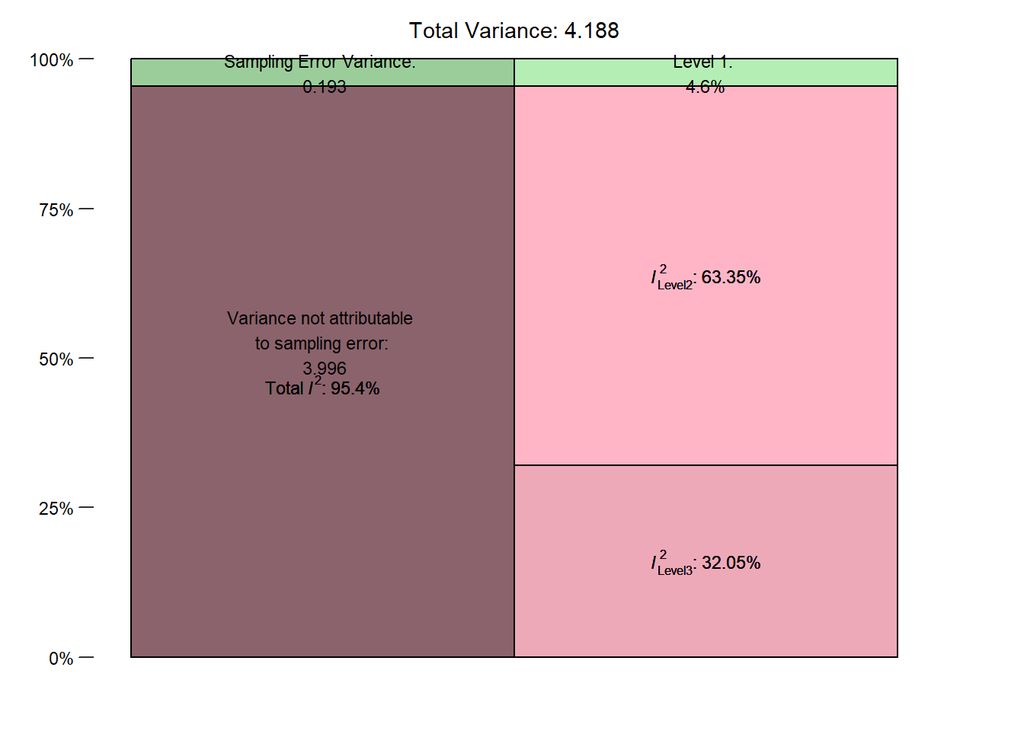

```
attr(,"class")
[1] "mlm.variance.distribution" "list"
```

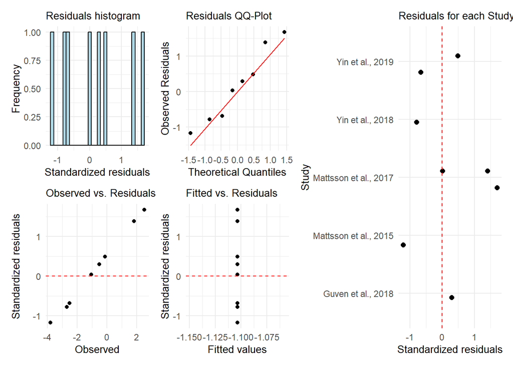

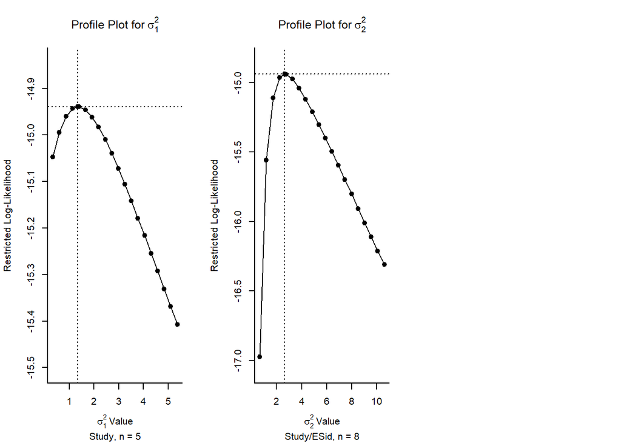

### Forest plot

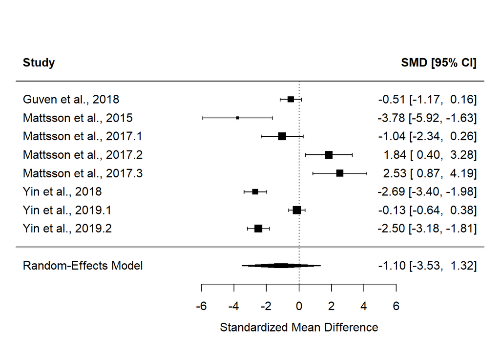

The meta-analysis comprised 8 comparisons from 5 control group clusters of 5 independent studies, so the random formula for Speed during feeding was ~1 | Study/ESid.

No difference between treatment and control groups (ES = -1.1034029 ± 0.8455413, CI95% = -3.5297157 to 1.32291, predicted interval -7.3314373 to 5.1246315), with high heterogeneity (i² = 95.4, Q = 121.9257852, p < 0.001 ) and variance explained by each component of $\sigma^2_{Study} = 1.34$, $\sigma^2_{ESid} = 2.65$.

# Publication bias

> **Small-study effect:** when small studies (with small sample sizes) tend to report large effect sizes. (Yang et al. 2023)

> While the PET method works best when the true effect captured by β0β0 is **zero**, PEESE shows a better performance when the true effect is **not** zero. Stanley and Doucouliagos ([2014](https://bookdown.org/MathiasHarrer/Doing_Meta_Analysis_in_R/references.html#ref-stanley2014meta)) therefore proposed to combine both methods, in order to balance out their individual strengths. The resulting approach is the PET-PEESE method. PET-PEESE uses the intercept β0 of either PET or PEESE as the estimate of the corrected true effect.

> Whether PET or PEESE is used depends on the size of the intercept calculated by the PET method. When β0PET is significantly larger than zero in a one-sided test with α = 0.05, we use the intercept of PEESE as the true effect size estimate. If PET’s intercept is not significantly larger than zero, we remain with the PET estimate.

> In most implementations of regression models in *R*, it is conventional to test the significance of coefficients using a two-sided test (i.e. we test if a ββ weight significantly differs from zero, no matter the direction). To assume a one-sided test with α = 0.05, we already regard the intercept as significant when p < 0.1, and when the estimate of β0 is larger than zero<sup>38</sup>. (Harrer et al., n.d.)

> **Time-lag bias:** when statistically significant (“positive” results) tend to be published earlier than those with statistically non-significant findings (“negative” results), leading to a decline in reported effect sizes over time (i.e., a decline effect). (Yang et al. 2023)

> Given that high heterogeneity may invalidate publication bias test, it is best to account for the potential heterogeneity when testing publication bias. (Yang et al. 2023)

> PET-PEESE performs poorly in research areas where there are only a few studies, all studies use small samples, and where there is very high heterogeneity of results from study to study. Nonetheless, the statistical properties of conventional meta-analysis approaches are much worse than PET-PEESE under these same conditions.(Stanley 2017)

So, **better use meta-regression dataset**, but requires larger dataset to avoid possible convergence issues.

```r
bias <- "Year"
mRE[[bias]] <- rma.mv(yi, VCV, random = RE_formula, mods = ~Year, data = df, slab = Study,
    method = "REML", test = "t", dfs = "contain", level = 95)
mRE[[bias]] <- robust(mRE[[bias]], cluster = df$Study, clubSandwich = TRUE)
mRE[[bias]] <- additional_results(mRE[[bias]])
mRE[[bias]][["pi"]] <- predict(mRE[[bias]], newmods = c(0, mean(df$Year)), digits = 2)

print(bias)
```

```
[1] "Year"
```

```r
summary(mRE[[bias]])
```

```
Multivariate Meta-Analysis Model (k = 8; method: REML)

  logLik  Deviance       AIC       BIC      AICc
-13.0216   26.0432   34.0432   33.2102   74.0432

Variance Components:

            estim    sqrt  nlvls  fixed      factor
sigma^2.1  2.3479  1.5323      5     no       Study
sigma^2.2  2.6950  1.6416      8     no  Study/ESid

Test for Residual Heterogeneity:
QE(df = 6) = 118.5035, p-val < .0001

Number of estimates:   8
Number of clusters:    5
Estimates per cluster: 0-3 (mean: 0.14, median: 0)

Test of Moderators (coefficient 2):¹
F(df1 = 1, df2 = 1.44) = 0.1613, p-val = 0.7395

Model Results:

          estimate         se¹     tval¹    df¹    pval¹        ci.lb¹
intrcpt  -692.2507  1721.2538   -0.4022   1.44   0.7392   -11694.2675
Year        0.3425     0.8529    0.4016   1.44   0.7395       -5.1060
              ci.ub¹
intrcpt  10309.7661
Year         5.7911

---
Signif. codes:  0 '***' 0.001 '**' 0.01 '*' 0.05 '.' 0.1 ' ' 1

1) results based on cluster-robust inference (var-cov estimator: CR2,
   approx t/F-tests and confidence intervals, df: Satterthwaite approx)
```

```r
mRE[[bias]][["pi"]]
```

```
     pred      se     ci.lb    ci.ub     pi.lb    pi.ub
1 -692.25 1721.25 -11694.27 10309.77 -11694.28 10309.78
2   -1.19    1.00     -4.58     2.20     -9.50     7.12
```

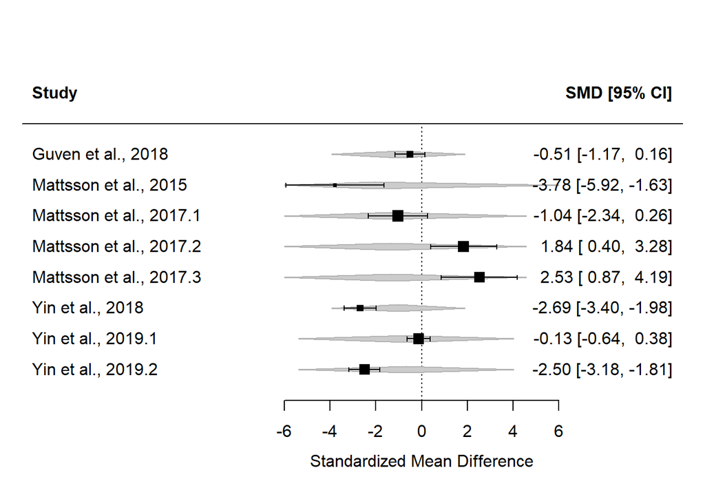

```r
plot_timelagbias <- bubble_plot(mRE[[bias]], mod = "Year", group = "Study", xlab = "Publication year",
    ylab = "Effect size (SMD)", legend.pos = "none", colorby = "Publication year",
    colormap = colormap)

forest(mRE[[bias]])
```

```r
# PET
df$ESSE <- sqrt(df$vi)  ## sampling error for ES

bias <- "PET"
mRE[[bias]] <- rma.mv(yi, VCV, random = RE_formula, mods = ~ESSE, data = df, slab = Study,
    method = "REML", test = "t", dfs = "contain", level = 95)
mRE[[bias]] <- robust(mRE[[bias]], cluster = df$Study, clubSandwich = TRUE)
mRE[[bias]] <- additional_results(mRE[[bias]])
mRE[[bias]][["pi"]] <- predict(mRE[[bias]], newmods = c(0, mean(df$Year)), digits = 2)

# if estimate is significant, assumes a quadratic association between sampling
# error and effect sizes to avoid a downwardly biased estimate of the
# bias-corrected overall effect:

# PEESE
if (mRE[[bias]]$pval[1] < 0.1) {
    mname <- "PEESE"
    mRE[[mname]] <- rma.mv(yi, VCV, random = RE_formula, mods = ~vi, data = df, slab = Study,
        method = "REML", test = "t", dfs = "contain", level = 95)
    mRE[[mname]] <- robust(mRE[[mname]], cluster = df$Study, clubSandwich = TRUE)
    mRE[[mname]] <- additional_results(mRE[[mname]])
    mRE[[mname]][["pi"]] <- predict(mRE[[mname]], newmods = c(0, mean(df$Year)),
        digits = 2)
    bias <- mname
}

# conditional estimate it it is significant there is no longer a single average
# effect (since the effect depends on the value of the moderator), so if we
# want to estimate the size of the effect, we have to specify a value for the
# moderator. One possibility is to estimate the ES based on the average of the
# moderator of all trials included in the meta-analysis.
```

#### Plots

```
[1] "PET"
```

```
Multivariate Meta-Analysis Model (k = 8; method: REML)

  logLik  Deviance       AIC       BIC      AICc
-13.1438   26.2875   34.2875   33.4546   74.2875

Variance Components:

            estim    sqrt  nlvls  fixed      factor
sigma^2.1  2.1263  1.4582      5     no       Study
sigma^2.2  2.8854  1.6987      8     no  Study/ESid

Test for Residual Heterogeneity:
QE(df = 6) = 118.4130, p-val < .0001

Number of estimates:   8
Number of clusters:    5
Estimates per cluster: 0-3 (mean: 0.14, median: 0)

Test of Moderators (coefficient 2):¹
F(df1 = 1, df2 = 2.04) = 0.0001, p-val = 0.9941

Model Results:

         estimate      se¹     tval¹    df¹    pval¹     ci.lb¹    ci.ub¹
intrcpt   -1.1309  1.8501   -0.6113   2.88   0.5859    -7.1620    4.9002
ESSE      -0.0402  4.8374   -0.0083   2.04   0.9941   -20.5048   20.4243

---
Signif. codes:  0 '***' 0.001 '**' 0.01 '*' 0.05 '.' 0.1 ' ' 1

1) results based on cluster-robust inference (var-cov estimator: CR2,
   approx t/F-tests and confidence intervals, df: Satterthwaite approx)
```

```
    pred      se     ci.lb    ci.ub     pi.lb    pi.ub
1  -1.13    1.85     -7.16     4.90    -10.60     8.34
2 -82.28 9757.73 -41371.72 41207.15 -41371.72 41207.15
```

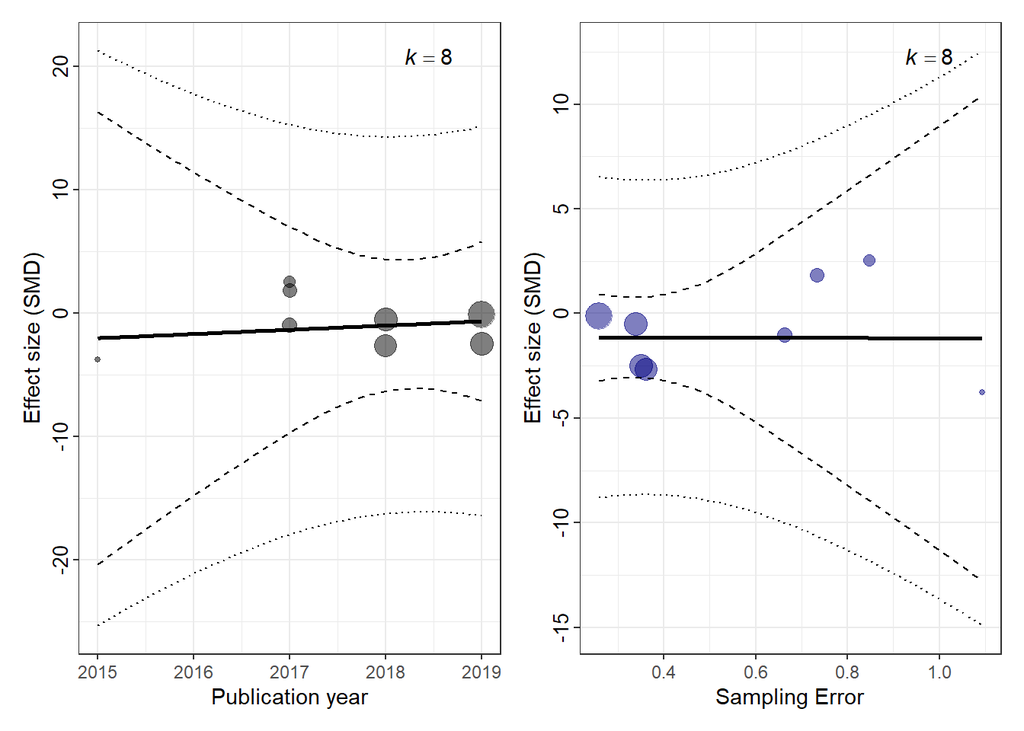

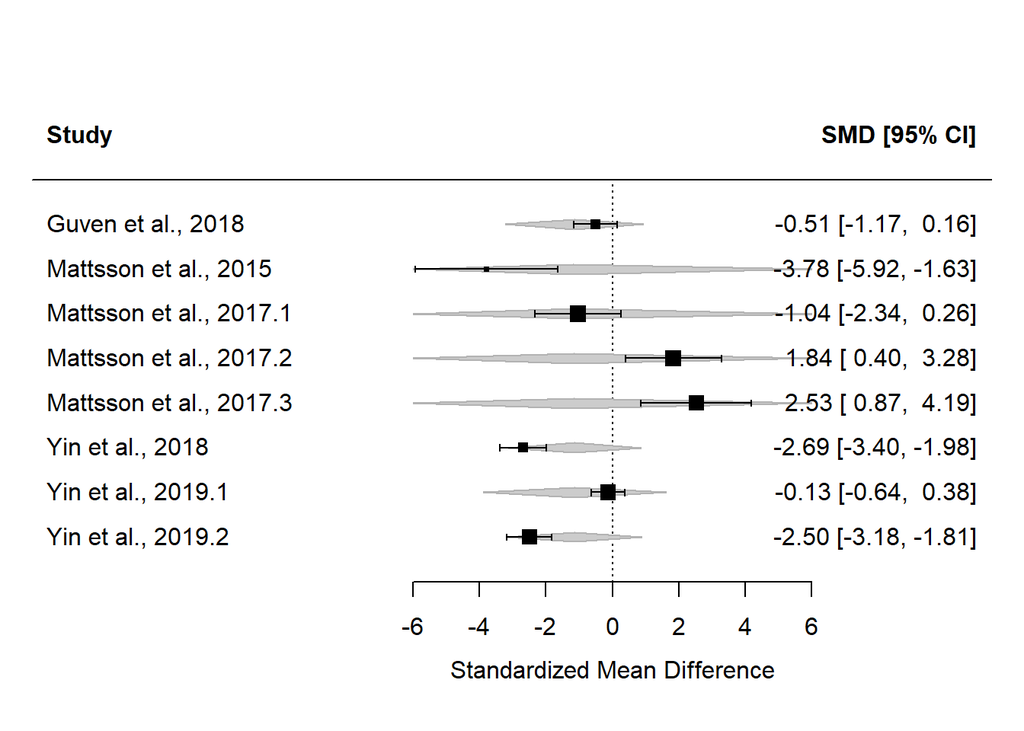

**Small-study effect** The regression slope of the extended Egger’s regression is $\sqrt{SMDSE} = -0.0402238$ is it statistically different from zero?`

If p<0.050: Smaller studies (with larger sampling error) have larger effect sizes –> small-study effect exists in this dataset. Data is assymmetrically distributed in the funnel plot.

If p>=0.050 no small-study effect exists in this dataset. Smaller studies (with larger sampling error) do not have larger effect sizes –> no small-study effect exists in this dataset. Data is symmetrically distributed in the funnel plot.

If p<0.050: studies with statistically significant findings tend to be published earlier than these with “negative” results, i.e. time-lag bias exists in this dataset

If p>=0.050: studies with statistically significant findings **do not** tend to be published earlier than these with “negative” results, i.e. no time-lag bias exists in this dataset

### Sensitivity analysis: publication bias with adapted SE

> Egger’s regression and its variants suffer from low power and poor performance when there are fewer than 20 effect sizes, or when the overall effect is large. (Nakagawa et al. 2022)

> Instead of the sample size (n1 + n2), however, for a meta-analysis of SMD or lnRR, we propose using the ‘effective sample size’ because it accounts for unbalanced sampling (cf. Stanley, 2005).(Nakagawa et al. 2022)

```r
# calculate modified SE based on effective sample size
df$ess_vi <- with(df, sqrt((n_treat + n_ctrl)/(n_treat * n_ctrl)))
df$ess_SE <- sqrt(df$ess_vi)  ## sampling error for ES

# PET + year
bias2 <- "PET sensitivity"
mRE[[bias2]] <- rma.mv(yi, VCV, random = RE_formula, mods = ~ess_SE, data = df, slab = Study,
    method = "REML", test = "t", dfs = "contain", level = 95)
mRE[[bias2]] <- robust(mRE[[bias2]], cluster = df$Study, clubSandwich = TRUE)
mRE[[bias2]] <- additional_results(mRE[[bias2]])
mRE[[bias2]][["pi"]] <- predict(mRE[[bias2]], newmods = c(0, mean(df$Year)), digits = 2)

# PEESE + year
if (mRE[[bias2]]$pval[1] < 0.1) {
    mname <- "PEESE sensitivity"
    mRE[[mname]] <- rma.mv(yi, VCV, random = RE_formula, mods = ~ess_vi, data = df,
        slab = Study, method = "REML", test = "t", dfs = "contain", level = 95)
    mRE[[mname]] <- robust(mRE[[mname]], cluster = df$Study, clubSandwich = TRUE)
    mRE[[mname]] <- additional_results(mRE[[mname]])
    mRE[[mname]][["pi"]] <- predict(mRE[[mname]], newmods = c(0, mean(df$Year)),
        digits = 2)
    bias2 <- mname
}
```

If the results are the same, indicates the robustness of the small-study test.

#### Plots

```r
print(bias2)
```

```
[1] "PET sensitivity"
```

```r
summary(mRE[[bias2]])
```

```
Multivariate Meta-Analysis Model (k = 8; method: REML)

  logLik  Deviance       AIC       BIC      AICc
-12.9579   25.9157   33.9157   33.0828   73.9157

Variance Components:

            estim    sqrt  nlvls  fixed      factor
sigma^2.1  1.4831  1.2178      5     no       Study
sigma^2.2  3.0003  1.7321      8     no  Study/ESid

Test for Residual Heterogeneity:
QE(df = 6) = 119.8983, p-val < .0001

Number of estimates:   8
Number of clusters:    5
Estimates per cluster: 0-3 (mean: 0.14, median: 0)

Test of Moderators (coefficient 2):¹
F(df1 = 1, df2 = 2.27) = 0.2131, p-val = 0.6849

Model Results:

         estimate      se¹     tval¹    df¹    pval¹     ci.lb¹    ci.ub¹
intrcpt   -3.5953  4.6251   -0.7774   2.53   0.5030   -19.9832   12.7925
ess_SE     3.9967  8.6575    0.4616   2.27   0.6849   -29.3507   37.3440

---
Signif. codes:  0 '***' 0.001 '**' 0.01 '*' 0.05 '.' 0.1 ' ' 1

1) results based on cluster-robust inference (var-cov estimator: CR2,
   approx t/F-tests and confidence intervals, df: Satterthwaite approx)
```

```r
mRE[[bias2]][["pi"]]
```

```
     pred       se     ci.lb    ci.ub     pi.lb    pi.ub
1   -3.60     4.63    -19.98    12.79    -21.62    14.43
2 8059.67 17461.86 -59204.53 75323.88 -59204.53 75323.88
```

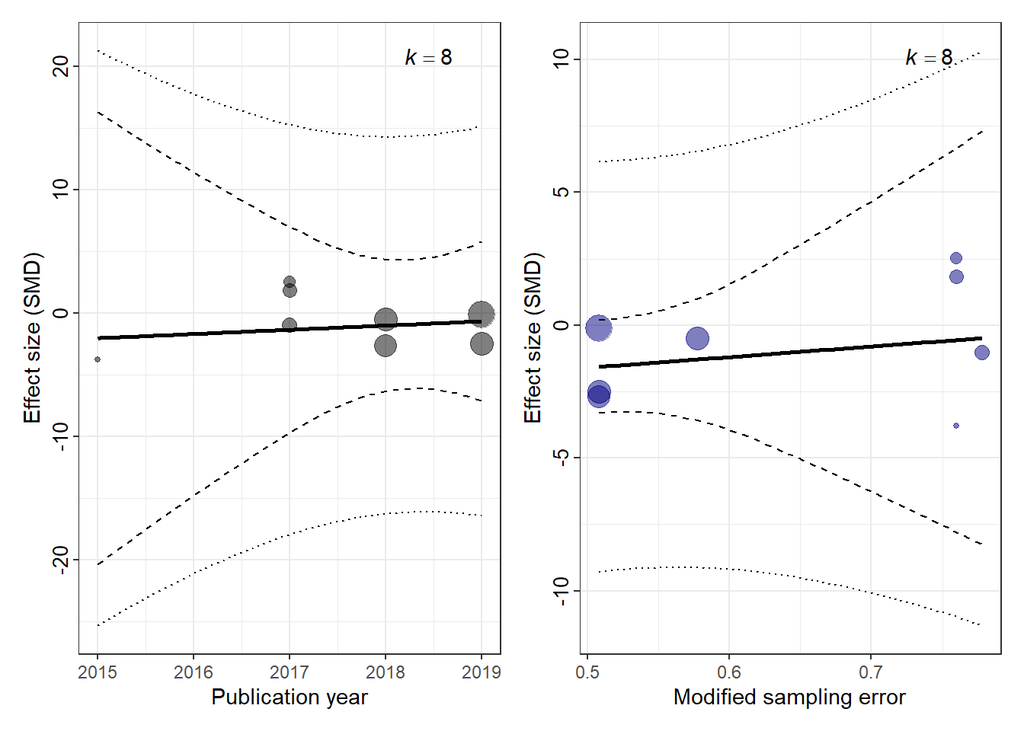

```r
if (mRE[["PET sensitivity"]]$pval[1] < 0.1) {
    plot_smallstudybias <- bubble_plot(mRE[[bias2]], mod = "ess_vi", group = "Study",
        xlab = "Modified sampling error variance", ylab = "Effect size (SMD)", legend.pos = "none",
        colorby = "Variance", colormap = colormap)
} else {
    plot_smallstudybias <- bubble_plot(mRE[[bias2]], mod = "ess_SE", group = "Study",
        xlab = "Modified sampling error", ylab = "Effect size (SMD)", legend.pos = "none",
        colorby = "Variance", colormap = colormap)
}

print(plot_timelagbias + plot_smallstudybias)
```

```r
# forest(mRE[[bias]])
```

# Sensitivity

## Rho range

```r
if (VCVrho != 0) {

    rho_range <- c(0, 0.25, 0.75, 0.9)  # assume a range values of rho

    for (j in 1:length(rho_range)) {

        mname <- paste("rho", rho_range[j], sep = "_")

        VCV2 <- vcalc(vi, cluster = interaction(df$EScluster, df$Study), obs = ESid,
            data = df, rho = rho_range[j])

        mRE[[mname]] <- rma.mv(yi, VCV2, random = RE_formula, data = df, slab = Study,
            method = "REML", test = "t", dfs = "contain", level = 95)
        mRE[[mname]] <- robust(mRE[[mname]], cluster = df$Study, clubSandwich = TRUE)
        mRE[[mname]] <- additional_results(mRE[[mname]])
    }
}
```

##Leave Embryo or Unclear out + Rho range

## Leave one out + Rho range

```r
if (VCVrho != 0) {
    rho_range <- c(0.25, 0.5, 0.75, 0.9)
} else {
    rho_range <- 0
}

for (i in sort(unique(df$Study))) {

    df_temp <- df[df$Study != i, ]

    for (j in 1:length(rho_range)) {

        mname <- paste("rho", rho_range[j], "l1o", i, sep = "_")
        print(mname)
        VCV2 <- vcalc(vi, cluster = interaction(df_temp$EScluster, df_temp$Study),
            obs = ESid, data = df_temp, rho = rho_range[j])

        mRE[[mname]] <- rma.mv(yi, VCV2, random = RE_formula, data = df_temp, slab = Study,
            method = "REML", test = "t", dfs = "contain", level = 95)
        mRE[[mname]] <- robust(mRE[[mname]], cluster = df_temp$Study, clubSandwich = TRUE)
        mRE[[mname]] <- additional_results(mRE[[mname]])
    }
}
```

```
[1] "rho_0.25_l1o_Guven et al., 2018"
[1] "rho_0.5_l1o_Guven et al., 2018"
[1] "rho_0.75_l1o_Guven et al., 2018"
[1] "rho_0.9_l1o_Guven et al., 2018"
[1] "rho_0.25_l1o_Mattsson et al., 2015"
[1] "rho_0.5_l1o_Mattsson et al., 2015"
[1] "rho_0.75_l1o_Mattsson et al., 2015"
[1] "rho_0.9_l1o_Mattsson et al., 2015"
[1] "rho_0.25_l1o_Mattsson et al., 2017"
[1] "rho_0.5_l1o_Mattsson et al., 2017"
[1] "rho_0.75_l1o_Mattsson et al., 2017"
[1] "rho_0.9_l1o_Mattsson et al., 2017"
[1] "rho_0.25_l1o_Yin et al., 2018"
[1] "rho_0.5_l1o_Yin et al., 2018"
[1] "rho_0.75_l1o_Yin et al., 2018"
[1] "rho_0.9_l1o_Yin et al., 2018"
[1] "rho_0.25_l1o_Yin et al., 2019"
[1] "rho_0.5_l1o_Yin et al., 2019"
[1] "rho_0.75_l1o_Yin et al., 2019"
[1] "rho_0.9_l1o_Yin et al., 2019"
```

# Tables

|  | n studies | n ES clusters | n ES | overall effect | standard error | p-value | Lower CI | Upper CI | Lower PI | Upper PI | Q | Q p-value | $I^2$$_{total}$ | $I^2$$_{Study}$ | $I^2$$_{ES}$ | $\sigma^2$$_{Study}$ | $\sigma^2$$_{ES}$ |
| --- | --- | --- | --- | --- | --- | --- | --- | --- | --- | --- | --- | --- | --- | --- | --- | --- | --- |
| ML | 5 | 8 | NA | -1.10 | 0.8 | 0.2577 | -3.43 | 1.22 | -7.12 | 4.91 | 121.93 | 0 | 95.40 | 32.05 | 63.35 | 1.34 | 2.65 |
| ML_RobVar | 5 | 8 | NA | -1.10 | 0.8 | 0.2673 | -3.53 | 1.32 | -7.33 | 5.12 | 121.93 | 0 | 95.40 | 32.05 | 63.35 | 1.34 | 2.65 |
| Year | 5 | 8 | NA | -692.25 | 1721.3 | 0.7392 | -11694.27 | 10309.77 | -11694.28 | 10309.78 | 118.50 | 0 | 96.32 | 44.84 | 51.47 | 2.35 | 2.69 |
| PET | 5 | 8 | NA | -1.13 | 1.9 | 0.5859 | -7.16 | 4.90 | -10.60 | 8.34 | 118.41 | 0 | 96.30 | 40.86 | 55.44 | 2.13 | 2.89 |
| PET sensitivity | 5 | 8 | NA | -3.60 | 4.6 | 0.5030 | -19.98 | 12.79 | -21.62 | 14.43 | 119.90 | 0 | 95.88 | 31.72 | 64.16 | 1.48 | 3.00 |
| rho_0 | 5 | 8 | NA | -1.09 | 0.9 | 0.2792 | -3.56 | 1.38 | -7.41 | 5.23 | 92.34 | 0 | 95.53 | 37.50 | 58.02 | 1.62 | 2.50 |
| rho_0.25 | 5 | 8 | NA | -1.10 | 0.9 | 0.2732 | -3.55 | 1.35 | -7.37 | 5.18 | 98.54 | 0 | 95.46 | 34.84 | 60.62 | 1.48 | 2.58 |
| rho_0.75 | 5 | 8 | NA | -1.11 | 0.8 | 0.2613 | -3.51 | 1.29 | -7.29 | 5.07 | 200.01 | 0 | 95.33 | 29.13 | 66.20 | 1.20 | 2.73 |
| rho_0.9 | 5 | 8 | NA | -1.11 | 0.8 | 0.2578 | -3.50 | 1.28 | -7.27 | 5.04 | 427.23 | 0 | 95.29 | 27.31 | 67.98 | 1.12 | 2.78 |
| rho_0.25_l1o_Guven et al., 2018 | 4 | 7 | NA | -1.30 | 1.1 | 0.3178 | -4.83 | 2.24 | -9.56 | 6.97 | 95.25 | 0 | 95.91 | 44.50 | 51.41 | 2.38 | 2.75 |
| rho_0.5_l1o_Guven et al., 2018 | 4 | 7 | NA | -1.30 | 1.1 | 0.3130 | -4.81 | 2.21 | -9.52 | 6.91 | 118.73 | 0 | 95.86 | 42.33 | 53.54 | 2.24 | 2.83 |
| rho_0.75_l1o_Guven et al., 2018 | 4 | 7 | NA | -1.31 | 1.1 | 0.3082 | -4.79 | 2.17 | -9.47 | 6.86 | 198.44 | 0 | 95.81 | 40.06 | 55.75 | 2.09 | 2.91 |
| rho_0.9_l1o_Guven et al., 2018 | 4 | 7 | NA | -1.31 | 1.0 | 0.3053 | -4.78 | 2.15 | -9.44 | 6.82 | 427.02 | 0 | 95.78 | 38.65 | 57.13 | 2.00 | 2.96 |
| rho_0.25_l1o_Mattsson et al., 2015 | 4 | 7 | NA | -0.64 | 0.8 | 0.5068 | -3.43 | 2.15 | -7.47 | 6.20 | 92.19 | 0 | 95.37 | 24.64 | 70.73 | 0.90 | 2.60 |
| rho_0.5_l1o_Mattsson et al., 2015 | 4 | 7 | NA | -0.65 | 0.8 | 0.4953 | -3.41 | 2.11 | -7.43 | 6.13 | 115.48 | 0 | 95.30 | 21.47 | 73.83 | 0.78 | 2.67 |
| rho_0.75_l1o_Mattsson et al., 2015 | 4 | 7 | NA | -0.66 | 0.8 | 0.4837 | -3.39 | 2.07 | -7.39 | 6.07 | 192.78 | 0 | 95.23 | 18.16 | 77.08 | 0.65 | 2.75 |
| rho_0.9_l1o_Mattsson et al., 2015 | 4 | 7 | NA | -0.67 | 0.8 | 0.4766 | -3.39 | 2.05 | -7.37 | 6.04 | 417.28 | 0 | 95.19 | 16.11 | 79.09 | 0.57 | 2.79 |
| rho_0.25_l1o_Mattsson et al., 2017 | 4 | 5 | NA | -1.77 | 0.6 | 0.0638 | -3.76 | 0.21 | -7.11 | 3.56 | 67.79 | 0 | 93.45 | 0.00 | 93.45 | 0.00 | 1.92 |
| rho_0.5_l1o_Mattsson et al., 2017 | 4 | 5 | NA | -1.78 | 0.6 | 0.0637 | -3.76 | 0.21 | -7.12 | 3.56 | 88.32 | 0 | 93.49 | 0.00 | 93.49 | 0.00 | 1.93 |
| rho_0.75_l1o_Mattsson et al., 2017 | 4 | 5 | NA | -1.78 | 0.6 | 0.0636 | -3.77 | 0.21 | -7.12 | 3.56 | 147.43 | 0 | 93.54 | 0.00 | 93.54 | 0.00 | 1.95 |
| rho_0.9_l1o_Mattsson et al., 2017 | 4 | 5 | NA | -1.78 | 0.6 | 0.0635 | -3.77 | 0.21 | -7.13 | 3.56 | 303.50 | 0 | 93.57 | 0.00 | 93.57 | 0.00 | 1.95 |
| rho_0.25_l1o_Yin et al., 2018 | 4 | 7 | NA | -0.75 | 0.9 | 0.4843 | -3.91 | 2.40 | -8.33 | 6.82 | 73.18 | 0 | 95.17 | 31.54 | 63.63 | 1.39 | 2.80 |
| rho_0.5_l1o_Yin et al., 2018 | 4 | 7 | NA | -0.76 | 0.9 | 0.4765 | -3.89 | 2.36 | -8.29 | 6.77 | 95.45 | 0 | 95.11 | 28.84 | 66.27 | 1.25 | 2.87 |
| rho_0.75_l1o_Yin et al., 2018 | 4 | 7 | NA | -0.77 | 0.9 | 0.4686 | -3.87 | 2.33 | -8.26 | 6.71 | 167.74 | 0 | 95.05 | 26.03 | 69.02 | 1.11 | 2.96 |
| rho_0.9_l1o_Yin et al., 2018 | 4 | 7 | NA | -0.78 | 0.9 | 0.4638 | -3.86 | 2.31 | -8.23 | 6.68 | 375.30 | 0 | 95.01 | 24.29 | 70.72 | 1.03 | 3.00 |
| rho_0.25_l1o_Yin et al., 2019 | 4 | 6 | NA | -1.14 | 1.2 | 0.3999 | -4.93 | 2.64 | -9.61 | 7.33 | 58.24 | 0 | 94.60 | 47.88 | 46.72 | 2.72 | 2.66 |
| rho_0.5_l1o_Yin et al., 2019 | 4 | 6 | NA | -1.15 | 1.2 | 0.3976 | -4.92 | 2.63 | -9.59 | 7.30 | 60.77 | 0 | 94.57 | 45.68 | 48.90 | 2.59 | 2.77 |
| rho_0.75_l1o_Yin et al., 2019 | 4 | 6 | NA | -1.15 | 1.2 | 0.3953 | -4.92 | 2.62 | -9.57 | 7.27 | 78.82 | 0 | 94.55 | 43.44 | 51.10 | 2.45 | 2.88 |
| rho_0.9_l1o_Yin et al., 2019 | 4 | 6 | NA | -1.15 | 1.2 | 0.3939 | -4.92 | 2.61 | -9.56 | 7.25 | 139.31 | 0 | 94.53 | 42.09 | 52.44 | 2.36 | 2.94 |

|  | ML | ML_RobVar | Year | PET | PET.sensitivity | rho_0 | rho_0.25 | rho_0.75 | rho_0.9 | rho_0.25_l1o_Guven.et.al...2018 | rho_0.5_l1o_Guven.et.al...2018 | rho_0.75_l1o_Guven.et.al...2018 | rho_0.9_l1o_Guven.et.al...2018 | rho_0.25_l1o_Mattsson.et.al...2015 | rho_0.5_l1o_Mattsson.et.al...2015 | rho_0.75_l1o_Mattsson.et.al...2015 | rho_0.9_l1o_Mattsson.et.al...2015 | rho_0.25_l1o_Mattsson.et.al...2017 | rho_0.5_l1o_Mattsson.et.al...2017 | rho_0.75_l1o_Mattsson.et.al...2017 | rho_0.9_l1o_Mattsson.et.al...2017 | rho_0.25_l1o_Yin.et.al...2018 | rho_0.5_l1o_Yin.et.al...2018 | rho_0.75_l1o_Yin.et.al...2018 | rho_0.9_l1o_Yin.et.al...2018 | rho_0.25_l1o_Yin.et.al...2019 | rho_0.5_l1o_Yin.et.al...2019 | rho_0.75_l1o_Yin.et.al...2019 | rho_0.9_l1o_Yin.et.al...2019 |
| --- | --- | --- | --- | --- | --- | --- | --- | --- | --- | --- | --- | --- | --- | --- | --- | --- | --- | --- | --- | --- | --- | --- | --- | --- | --- | --- | --- | --- | --- |
| logLik: | -14.93913229764634 | -14.93913229764634 | -13.02160025960996 | -13.14377232756538 | -12.95786461273159 | -14.9766736308807 | -14.95788546031273 | -14.92038616615558 | -14.90912884947879 | -13.19120901374212 | -13.17785000555029 | -13.16456166703075 | -13.15661471069494 | -12.38281235202252 | -12.36548356569319 | -12.34815066470311 | -12.33773828734864 | -7.324162593014112 | -7.328532598498166 | -7.332932163714005 | -7.335585826097949 | -12.92805949180201 | -12.91433369610608 | -12.90062214641657 | -12.89239306629639 | -11.14619481871848 | -11.13820757211795 | -11.1301612321815 | -11.12530478543803 |
| deviance: | 29.87826459529268 | 29.87826459529268 | 26.04320051921992 | 26.28754465513076 | 25.91572922546317 | 29.95334726176141 | 29.91577092062546 | 29.84077233231116 | 29.81825769895757 | 26.38241802748424 | 26.35570001110058 | 26.32912333406151 | 26.31322942138988 | 24.76562470404504 | 24.73096713138638 | 24.69630132940623 | 24.67547657469727 | 14.64832518602822 | 14.65706519699633 | 14.66586432742801 | 14.6711716521959 | 25.85611898360402 | 25.82866739221215 | 25.80124429283314 | 25.78478613259278 | 22.29238963743695 | 22.27641514423591 | 22.26032246436301 | 22.25060957087607 |
| AIC: | 35.87826459529268 | 35.87826459529268 | 34.04320051921992 | 34.28754465513076 | 33.91572922546317 | 35.95334726176141 | 35.91577092062546 | 35.84077233231116 | 35.81825769895757 | 32.38241802748424 | 32.35570001110058 | 32.32912333406151 | 32.31322942138988 | 30.76562470404504 | 30.73096713138638 | 30.69630132940623 | 30.67547657469727 | 20.64832518602822 | 20.65706519699633 | 20.66586432742801 | 20.6711716521959 | 31.85611898360402 | 31.82866739221215 | 31.80124429283314 | 31.78478613259278 | 28.29238963743695 | 28.27641514423591 | 28.26032246436301 | 28.25060957087607 |
| BIC: | 35.71599504245862 | 35.71599504245862 | 33.21023839613213 | 33.45458253204298 | 33.08276710237539 | 35.79107770892735 | 35.75350136779139 | 35.6785027794771 | 35.65598814612351 | 31.75769643516841 | 31.73097841878475 | 31.70440174174567 | 31.68850782907405 | 30.1409031117292 | 30.10624553907054 | 30.0715797370904 | 30.05075498238143 | 18.8072082693879 | 18.815948280356 | 18.82474741078768 | 18.83005473555557 | 31.23139739128819 | 31.20394579989632 | 31.1765227005173 | 31.16006454027695 | 27.12070337473926 | 27.10472888153821 | 27.08863620166531 | 27.07892330817837 |
| AICc: | 43.87826459529268 | 43.87826459529268 | 74.04320051921991 | 74.28754465513076 | 73.91572922546317 | 43.95334726176141 | 43.91577092062546 | 43.84077233231116 | 43.81825769895757 | 44.38241802748424 | 44.35570001110058 | 44.32912333406151 | 44.31322942138988 | 42.76562470404504 | 42.73096713138638 | 42.69630132940623 | 42.67547657469727 | 44.64832518602822 | 44.65706519699633 | 44.66586432742801 | 44.67117165219589 | 43.85611898360402 | 43.82866739221215 | 43.80124429283313 | 43.78478613259279 | 52.29238963743695 | 52.27641514423591 | 52.26032246436301 | 52.25060957087607 |

# Influential cases

> Outliers and influential cases can actually reveal patterns that may lead to new insights about study characteristics that could be acting as potential moderators (Viechtbauer and Cheung 2010)

Cook’s distance: examine what effect the deletion of the ith study has on the fitted values of all k studies simultaneously (Viechtbauer and Cheung 2010)

DFBETAS: directly examine the influence of deleting the ith case on each individual parameter estimate (Viechtbauer and Cheung 2010)

So if a point has high Cook’s Distance, use DFBETAS to identify witch estimate is mainly influenced (only makes sense for meta regression).

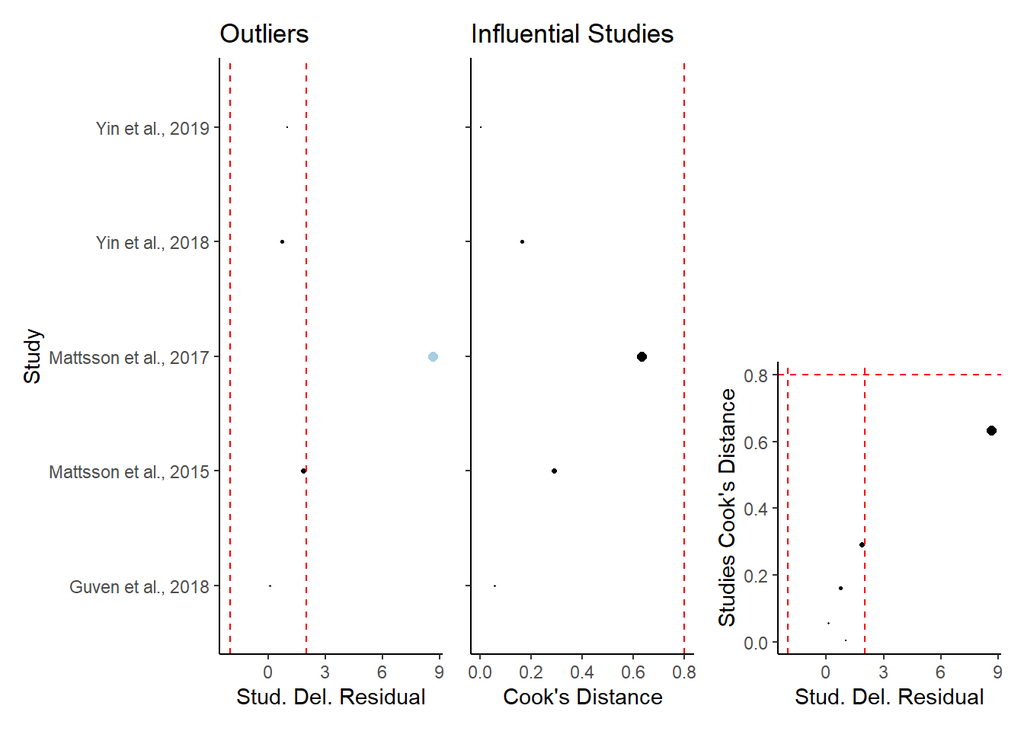

```r
influentialcases_plots(mRE, "ML_RobVar", "ML", 3)
```

# Multilevel meta-regression

SYRCLE PROTOCOL: Meta-regression will be used for outcomes with at least 10 experiments.

> The minimal number of studies or effect sizes required by a multilevel meta-regression remains unknown, albeit some simulation studies suggest that the estimates of model coefficients of a multilevel meta-regression are generally stable under various simulated situations.(Yang et al. 2023) … the complexity of parameterization of such a meta-regression requires a large dataset to make optimization algorithms free of convergence issues.(Yang et al. 2023)

## Model 1: Size, Duration, Development

```r
df_MR <- select(df, c("Year", "StudyID", "Study", "EScluster", "ESid", "DevelopmentalStage",
    "ExposureDurationDays", "ParticleSizeMean", "yi", "vi"))

mname1 <- "Base"
mname2 <- paste0(mname1, "_RobVar")

# are there differences between the different forms of DevelopmentalStage?
# mods_formula <- formula(~ ParticleSizeMean +
# ExposureDurationDays*DevelopmentalStage)

# at least one of the DevelopmentalStage levels is different than zero?
morethan1stages <- length(unique(df$DevelopmentalStage)) > 1
print(c("more than 1 developmental stage: ", morethan1stages))
```

```
[1] "more than 1 developmental stage: " "TRUE"
```

```r
if (morethan1stages) {
    mods_formula <- formula(~0 + ParticleSizeMean + ExposureDurationDays * DevelopmentalStage)
} else {
    # for Sensory-motor function
    mods_formula <- formula(~0 + ParticleSizeMean + ExposureDurationDays)
}

mMR[[mname1]] <- rma.mv(yi, VCV, random = RE_formula, mods = mods_formula, data = df_MR,
    slab = Study, method = "REML", test = "t", dfs = "contain", level = 95)  #it will only keep complete cases

nSt_MR <- mMR[[mname1]]$s.nlevels[1]  # number of studies
nEC_MR <- mMR[[mname1]]$s.nlevels[2]  # number of ESclusters/independent ES
nES_MR <- mMR[[mname1]]$s.nlevels[3]  # number of independent ES

if (length(mMR[[mname1]]$s.nlevels) == 3) {
    print(paste0("Number of studies: ", nSt_MR, ", number of ES clusters: ", nEC_MR,
        " and number of independent observations of ES: ", nES_MR))
} else {
    print(paste0("Number of studies: ", nSt_MR, " and number of independent observations of ES: ",
        nEC_MR))
}
```

```
[1] "Number of studies: 5 and number of independent observations of ES: 8"
```

```r
mMR[[mname2]] <- robust(mMR[[mname1]], cluster = df_MR$Study, clubSandwich = TRUE,
    verbose = TRUE)
```

[output not shown]

```r
mMR[[mname2]][["i2"]] <- i2_ml(mMR[[mname2]])
mMR[[mname2]][["icc"]] <- round(mMR[[mname2]]$sigma2/sum(mMR[[mname2]]$sigma2), 3)

if (n_outcome != 10) {
    anova(mMR[[mname2]], btt = c("DevelopmentalStage", "ExposureDurationDays", "ParticleSizeMean"))
} else if (n_outcome == 10) {
    # for Sensory-motor function
    anova(mMR[[mname2]], btt = c("ExposureDurationDays", "ParticleSizeMean"))
}
```

```
                  spec coefs      Fval df1   df2   pval
1   DevelopmentalStage   3:5    0.0000   3 -0.29     NA
2 ExposureDurationDays     2 1947.6234   1  1.03 0.0129 *
3     ParticleSizeMean     1    8.0086   1  1.29 0.1683
```

```r
m <- mMR[[mname2]]

summary(m)
```

```
Multivariate Meta-Analysis Model (k = 8; method: REML)

  logLik  Deviance       AIC       BIC      AICc
 -5.5498   11.0996   25.0996   18.7899  137.0996

Variance Components:

            estim    sqrt  nlvls  fixed      factor
sigma^2.1  0.0000  0.0000      5     no       Study
sigma^2.2  2.0982  1.4485      8     no  Study/ESid

Test for Residual Heterogeneity:
QE(df = 3) = 27.3384, p-val < .0001

Number of estimates:   8
Number of clusters:    5
Estimates per cluster: 0-3 (mean: 0.14, median: 0)

Model Results:

                            estimate      se¹      tval¹    df¹    pval¹
ParticleSizeMean             -0.1690  0.0597    -2.8300   1.29   0.1683
ExposureDurationDays          0.8033  0.0182    44.1319   1.03   0.0129
DevelopmentalStageLarva      15.0866  5.7933     2.6042   1.29   0.1853
DevelopmentalStageJuvenile  -11.3012  0.9741   -11.6017   1.02   0.0519
DevelopmentalStageAdult     -52.7769  1.1103   -47.5324   1.03   0.0121
                               ci.lb¹     ci.ub¹
ParticleSizeMean             -0.6207     0.2826
ExposureDurationDays          0.5876     1.0190   *
DevelopmentalStageLarva     -28.7143    58.8875
DevelopmentalStageJuvenile  -23.0210     0.4187   .
DevelopmentalStageAdult     -65.9951   -39.5586   *

---
Signif. codes:  0 '***' 0.001 '**' 0.01 '*' 0.05 '.' 0.1 ' ' 1

1) results based on cluster-robust inference (var-cov estimator: CR2,
   approx t/F-tests and confidence intervals, df: Satterthwaite approx)
```

```r
m$fit.stats
```

|  | ML | REML |
| --- | --- | --- |
| ll | -12.50737 | -5.549807 |
| dev | 21.88401 | 11.099613 |
| AIC | 39.01474 | 25.099613 |
| BIC | 39.57083 | 18.789899 |
| AICc | 151.01474 | 137.099613 |

#### Diagnostics plots

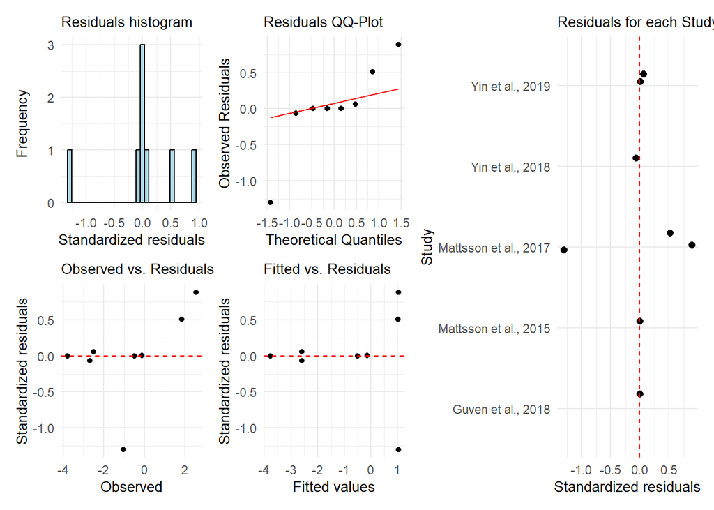

```r
diagnostic_plots(m)
```

#### Influential cases

(Nakagawa et al. 2021)

## Model 2: + Concentration

#### Diagnostics plots

#### Influential cases

#### Orchard plots

## Model 3: + ParticleMaterial

#### Diagnostics plots

#### Influential cases

#### Orchard plots

# Referências

Harrer, Mathias, Pim Cuijpers, Toshi A. Furukawa, and David D. Ebert. n.d. *Chapter 9 Publication Bias | Doing Meta-Analysis in R*. https://bookdown.org/MathiasHarrer/Doing_Meta_Analysis_in_R/pub-bias.html.

Nakagawa, Shinichi, Malgorzata Lagisz, Michael D. Jennions, Julia Koricheva, Daniel W. A. Noble, Timothy H. Parker, Alfredo Sánchez-Tójar, Yefeng Yang, and Rose E. O’Dea. 2022. “Methods for Testing Publication Bias in Ecological and Evolutionary Meta-Analyses.” *Methods in Ecology and Evolution* 13 (1): 4–21. https://doi.org/10.1111/2041-210X.13724.

Nakagawa, Shinichi, Malgorzata Lagisz, Rose E. O’Dea, Joanna Rutkowska, Yefeng Yang, Daniel W. A. Noble, and Alistair M. Senior. 2021. “The Orchard Plot: Cultivating a Forest Plot for Use in Ecology, Evolution, and Beyond.” *Research Synthesis Methods* 12 (1): 4–12. https://doi.org/10.1002/jrsm.1424.

Stanley, T. D. 2017. “Limitations of PET-PEESE and Other Meta-Analysis Methods.” *Social Psychological and Personality Science* 8 (5): 581–91. https://doi.org/10.1177/1948550617693062.

Viechtbauer, Wolfgang. 2010. “Conducting Meta-Analyses in R with the Metafor Package.” *Journal of Statistical Software* 36 (August): 1–48. https://doi.org/10.18637/jss.v036.i03.

———. 2022. “Konstantopoulos (2011) [the Metafor Package].” https://www.metafor-project.org/doku.php/analyses:konstantopoulos2011.

Viechtbauer, Wolfgang, and Mike W.-L. Cheung. 2010. “Outlier and Influence Diagnostics for Meta-Analysis.” *Research Synthesis Methods* 1 (2): 112–25. https://doi.org/10.1002/jrsm.11.

Yang, Yefeng, Malcolm Macleod, Jinming Pan, Malgorzata Lagisz, and Shinichi Nakagawa. 2023. “Advanced Methods and Implementations for the Meta-Analyses of Animal Models: Current Practices and Future Recommendations.” *Neuroscience & Biobehavioral Reviews* 146 (March): 105016. https://doi.org/10.1016/j.neubiorev.2022.105016.